# Statistical Analysis and Concepts with Python

### By: Bryan Hope

# Table of Contents

1. Introduction
2. Importing Libraries
3. Boston Dataset
4. Summary Statistics
5. Analysis of Variables
6. Correlation Methods
7. Visually inspecting variable relationships
8. Measuring Skewness
9. Transforming variable to reduce skewness
10. Comparing transformed and non-transformed variables
11. Build Linear Regression Model
12. Split Data for testing
13. Confidence Intervals
14. Hypothesis Testing
15. Model Summary
16. Residuals
17. Variable Importance
18. Conclusion

# Introduction

The purpose of this analysis is to demonstrate common statistical methods to analyze a data set using the python programming language. I will conduct some basic analysis of the variables and compare different methods that could be used with the goal of understanding relationships in the data. Understanding relationships in data can be very useful especially if the data is unfamiliar once there is an understanding of the cause and effect relationship of the data this information can be put to use for business planning to try to make affect a desirable outcome.

For this analysis, I have chosen to analyze housing data which most people are familiar with. The goal of this analysis to predict potential median values of homes in the Boston market. The Boston housing data comes from a 1978 census and contains 14 variables that can be used to analyze the data set.

When trying to determine real estate values a common approach is to use 'comps' or comparables of previous homes sold in nearby areas to determine the price of a home. Location is one of the primary factors that can predict the value of a home. Homes in desirable neighborhoods will generally sell for higher prices than less desirable neighborhoods a desirable neighborhood may have good schools, low crime, access to freeways, larger home size, and other amenities.

If we have a good data set then the data should reflect some of the common assumptions that are the foundations of the real estate market.

**Real Estate Market Assumptions**

- Location matters.
- Better locations will yield a higher home price.
- Larger homes will yield a higher home price.
- Close access to public transportation, freeways, employment locations, and other desirable places will fetch a higher price.
- Low crime areas are more desirable than high crime areas

In this analysis, I will be looking to validate these assumptions and also looking to see which of these assumptions provides the strongest relationship with the target variable which is the median home price. I will also be keeping an eye for any unique relationships that are not as common or are not commonly recognized as impacting the median price of a home. Finally, I will build a linear regression model to predict the median home prices in the Boston market based on the dataset.

Table of Contents

### Importing Libraries

```python
#For creating dataframes
import pandas as pd
import numpy as np
#For creates charts, graphs and plots
import seaborn as sns
#For creating charts, graphs and plots
import matplotlib.pyplot as plt
# For importing datasets
from sklearn import datasets
# For Biserial, Spearman Rank correlations
from scipy.stats import pointbiserialr, spearmanr
#For measuring skew and kurtosis
from scipy.stats import kurtosis, skew
#for Statsmodel Statistical Models
import statsmodels.api as sm
#Scipy Statistical models
from scipy import stats
#For supervised learning
from sklearn.model_selection import train_test_split
#For Regression Models
from sklearn.linear_model import LinearRegression
#For statistical measures
from sklearn.metrics import mean_squared_error,r2_score,mean_absolute_error
#Python Math library
import math
#For handling warnings
#For displaying images
from IPython.display import Image
#For displayng HTML
from IPython.core.display import HTML
import warnings
#Hide warnings
warnings.filterwarnings("ignore")
#Defining graph style
plt.style.use('ggplot')
```

Table of Contents

### Load the Boston dataset

```python
boston = datasets.load_boston()
```

```python
print(boston.DESCR)
```

```
.. _boston_dataset:

Boston house prices dataset
---------------------------

**Data Set Characteristics:**

    :Number of Instances: 506

    :Number of Attributes: 13 numeric/categorical predictive. Median Value (attribute 14) is usually the target.

    :Attribute Information (in order):
        - CRIM     per capita crime rate by town
        - ZN       proportion of residential land zoned for lots over 25,000 sq.ft.
        - INDUS    proportion of non-retail business acres per town
        - CHAS     Charles River dummy variable (= 1 if tract bounds river; 0 otherwise)
        - NOX      nitric oxides concentration (parts per 10 million)
        - RM       average number of rooms per dwelling
        - AGE      proportion of owner-occupied units built prior to 1940
        - DIS      weighted distances to five Boston employment centres
        - RAD      index of accessibility to radial highways
        - TAX      full-value property-tax rate per $10,000
        - PTRATIO  pupil-teacher ratio by town
        - B        1000(Bk - 0.63)^2 where Bk is the proportion of blacks by town
        - LSTAT    % lower status of the population
        - MEDV     Median value of owner-occupied homes in $1000's

    :Missing Attribute Values: None

    :Creator: Harrison, D. and Rubinfeld, D.L.

This is a copy of UCI ML housing dataset.
https://archive.ics.uci.edu/ml/machine-learning-databases/housing/


This dataset was taken from the StatLib library which is maintained at Carnegie Mellon University.

The Boston house-price data of Harrison, D. and Rubinfeld, D.L. 'Hedonic
prices and the demand for clean air', J. Environ. Economics & Management,
vol.5, 81-102, 1978.   Used in Belsley, Kuh & Welsch, 'Regression diagnostics
...', Wiley, 1980.   N.B. Various transformations are used in the table on
pages 244-261 of the latter.

The Boston house-price data has been used in many machine learning papers that address regression
problems.

.. topic:: References

   - Belsley, Kuh & Welsch, 'Regression diagnostics: Identifying Influential Data and Sources of Collinearity', Wiley, 1980. 244-261.
   - Quinlan,R. (1993). Combining Instance-Based and Model-Based Learning. In Proceedings on the Tenth International Conference of Machine Learning, 236-243, University of Massachusetts, Amherst. Morgan Kaufmann.
```

Table of Contents

Create a dataframe and load data into dataframe to view the data.

```python
features = pd.DataFrame(boston.data,columns=boston.feature_names)
features.head()
```

|  | CRIM | ZN | INDUS | CHAS | NOX | RM | AGE | DIS | RAD | TAX | PTRATIO | B | LSTAT |
| --- | --- | --- | --- | --- | --- | --- | --- | --- | --- | --- | --- | --- | --- |
| 0 | 0.00632 | 18.0 | 2.31 | 0.0 | 0.538 | 6.575 | 65.2 | 4.0900 | 1.0 | 296.0 | 15.3 | 396.90 | 4.98 |
| 1 | 0.02731 | 0.0 | 7.07 | 0.0 | 0.469 | 6.421 | 78.9 | 4.9671 | 2.0 | 242.0 | 17.8 | 396.90 | 9.14 |
| 2 | 0.02729 | 0.0 | 7.07 | 0.0 | 0.469 | 7.185 | 61.1 | 4.9671 | 2.0 | 242.0 | 17.8 | 392.83 | 4.03 |
| 3 | 0.03237 | 0.0 | 2.18 | 0.0 | 0.458 | 6.998 | 45.8 | 6.0622 | 3.0 | 222.0 | 18.7 | 394.63 | 2.94 |
| 4 | 0.06905 | 0.0 | 2.18 | 0.0 | 0.458 | 7.147 | 54.2 | 6.0622 | 3.0 | 222.0 | 18.7 | 396.90 | 5.33 |

### Adding the target variable to the dataframe

```python
features['Median_Value'] = boston.target
```

```python
features.head()
```

|  | CRIM | ZN | INDUS | CHAS | NOX | RM | AGE | DIS | RAD | TAX | PTRATIO | B | LSTAT | Median_Value |
| --- | --- | --- | --- | --- | --- | --- | --- | --- | --- | --- | --- | --- | --- | --- |
| 0 | 0.00632 | 18.0 | 2.31 | 0.0 | 0.538 | 6.575 | 65.2 | 4.0900 | 1.0 | 296.0 | 15.3 | 396.90 | 4.98 | 24.0 |
| 1 | 0.02731 | 0.0 | 7.07 | 0.0 | 0.469 | 6.421 | 78.9 | 4.9671 | 2.0 | 242.0 | 17.8 | 396.90 | 9.14 | 21.6 |
| 2 | 0.02729 | 0.0 | 7.07 | 0.0 | 0.469 | 7.185 | 61.1 | 4.9671 | 2.0 | 242.0 | 17.8 | 392.83 | 4.03 | 34.7 |
| 3 | 0.03237 | 0.0 | 2.18 | 0.0 | 0.458 | 6.998 | 45.8 | 6.0622 | 3.0 | 222.0 | 18.7 | 394.63 | 2.94 | 33.4 |
| 4 | 0.06905 | 0.0 | 2.18 | 0.0 | 0.458 | 7.147 | 54.2 | 6.0622 | 3.0 | 222.0 | 18.7 | 396.90 | 5.33 | 36.2 |

### Summary Statistics

```python
#Summary Statistics
features.describe()
```

|  | CRIM | ZN | INDUS | CHAS | NOX | RM | AGE | DIS | RAD | TAX | PTRATIO | B | LSTAT | Median_Value |
| --- | --- | --- | --- | --- | --- | --- | --- | --- | --- | --- | --- | --- | --- | --- |
| count | 506.000000 | 506.000000 | 506.000000 | 506.000000 | 506.000000 | 506.000000 | 506.000000 | 506.000000 | 506.000000 | 506.000000 | 506.000000 | 506.000000 | 506.000000 | 506.000000 |
| mean | 3.613524 | 11.363636 | 11.136779 | 0.069170 | 0.554695 | 6.284634 | 68.574901 | 3.795043 | 9.549407 | 408.237154 | 18.455534 | 356.674032 | 12.653063 | 22.532806 |
| std | 8.601545 | 23.322453 | 6.860353 | 0.253994 | 0.115878 | 0.702617 | 28.148861 | 2.105710 | 8.707259 | 168.537116 | 2.164946 | 91.294864 | 7.141062 | 9.197104 |
| min | 0.006320 | 0.000000 | 0.460000 | 0.000000 | 0.385000 | 3.561000 | 2.900000 | 1.129600 | 1.000000 | 187.000000 | 12.600000 | 0.320000 | 1.730000 | 5.000000 |
| 25% | 0.082045 | 0.000000 | 5.190000 | 0.000000 | 0.449000 | 5.885500 | 45.025000 | 2.100175 | 4.000000 | 279.000000 | 17.400000 | 375.377500 | 6.950000 | 17.025000 |
| 50% | 0.256510 | 0.000000 | 9.690000 | 0.000000 | 0.538000 | 6.208500 | 77.500000 | 3.207450 | 5.000000 | 330.000000 | 19.050000 | 391.440000 | 11.360000 | 21.200000 |
| 75% | 3.677083 | 12.500000 | 18.100000 | 0.000000 | 0.624000 | 6.623500 | 94.075000 | 5.188425 | 24.000000 | 666.000000 | 20.200000 | 396.225000 | 16.955000 | 25.000000 |
| max | 88.976200 | 100.000000 | 27.740000 | 1.000000 | 0.871000 | 8.780000 | 100.000000 | 12.126500 | 24.000000 | 711.000000 | 22.000000 | 396.900000 | 37.970000 | 50.000000 |

Table of Contents

## Analysis of Variables

**Continuous Variables:** CRIM, ZN, INDUS, NOX, RM, AGE, TAX, B, LSTAT, Median_Value

**Categorical Variables:** RAD, CHAS

With the following print statement we can see that the **CHAS** variable is binary.

```python
print(features['CHAS'].unique())
```

```
[0. 1.]
```

With the following print statement we can see that the **RAD** variable is categorical the categories may refer to ranking.

```python
features['RAD'].unique()
```

```
array([ 1.,  2.,  3.,  5.,  4.,  8.,  6.,  7., 24.])
```

### Correlation Methods

In order to find correlation among variables I will compare a few different methods for obtaining correlations. Since binary and categorical variables are representative data the numerical values should not be considered as continous numerical value.

- Binary and continuous variable correlation - Point Biserial Method
- Categorical and continuous variable correlation - Spearman Rank Correlation, Kendall's Tau Method
- Continuous and continuous variable correlation - Pearson Corerlation Method

**Note:** Scipy Point Biserial method produces the same result as Pandas pearsonr method

Table of Contents

## Correlation matrix for all variables

```python
#The methods below apply various correlation methods to the features dataframe.

#Pearson's correlation
pearson_corr = features.corr(method='pearson')
#Kendall's Tau correlation
kendall_corr = features.corr(method='kendall')
#Spearman's Rank Correlation
spearman_corr = features.corr(method='spearman')
```

### Point Biserial Correlation**

Binary to conitnuous variable correlation

```python
#Point Biserial Correlation
print('- - - - Scipy Point Biserial Correlation with CHAS variable - - - - ')
print('')
for i in features.columns:
    src = pointbiserialr(features['CHAS'], features[i])
    print('Point Biserial Correlation CHAS &',i,':',src[0])
```

```
- - - - Scipy Point Biserial Correlation with CHAS variable - - - -

Point Biserial Correlation CHAS & CRIM : -0.05589158222224148
Point Biserial Correlation CHAS & ZN : -0.04269671929612168
Point Biserial Correlation CHAS & INDUS : 0.06293802748966493
Point Biserial Correlation CHAS & CHAS : 0.9999999999999999
Point Biserial Correlation CHAS & NOX : 0.09120280684249511
Point Biserial Correlation CHAS & RM : 0.09125122504345658
Point Biserial Correlation CHAS & AGE : 0.08651777425454275
Point Biserial Correlation CHAS & DIS : -0.09917578017472785
Point Biserial Correlation CHAS & RAD : -0.007368240886077576
Point Biserial Correlation CHAS & TAX : -0.0355865175859114
Point Biserial Correlation CHAS & PTRATIO : -0.12151517365806241
Point Biserial Correlation CHAS & B : 0.04878848495516649
Point Biserial Correlation CHAS & LSTAT : -0.05392929837569434
Point Biserial Correlation CHAS & Median_Value : 0.17526017719029846
```

**If we compare the Point Biserial method above it matches the Pearson correlation method below**

```python
pearson_corr['CHAS']
```

```
CRIM           -0.055892
ZN             -0.042697
INDUS           0.062938
CHAS            1.000000
NOX             0.091203
RM              0.091251
AGE             0.086518
DIS            -0.099176
RAD            -0.007368
TAX            -0.035587
PTRATIO        -0.121515
B               0.048788
LSTAT          -0.053929
Median_Value    0.175260
Name: CHAS, dtype: float64
```

### Spearman's Rank Correlation

Categorical to Continious variable correlation

Since this is the Spearman Rank Correlation *we are only interested in how the categorical variable RAD correlates to continous variables.*

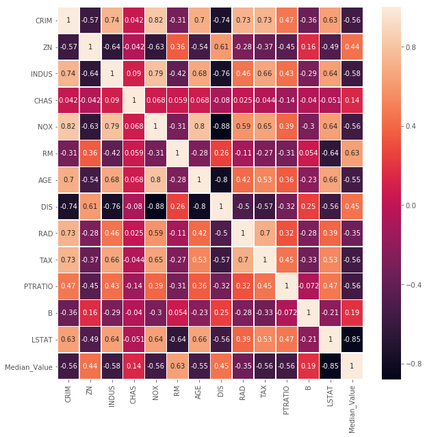

```python
fig, ax = plt.subplots(figsize=(10,10))
sns.heatmap(spearman_corr, annot=True, linewidths=.5, ax=ax)
```

Spearman Rank correlation shows that the **RAD** variable has a fairly strong correlation with **CRIM** and **TAX** but the target variable **Median_Value** does not show strong correlation with **RAD**.

### Kendall's Tau Correlation

Categorical to continuous variable correlation

Since this is the Kendall's Tau Correlation **we are only interested in how the categorical variable RAD correlates to continous variables.**

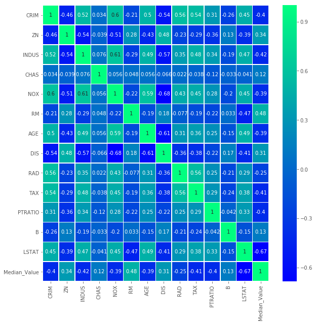

```python
fig, ax = plt.subplots(figsize=(10,10))
sns.heatmap(kendall_corr, annot=True, linewidths=.5, ax=ax,cmap="winter")
```

Kendall's Tau Correlation also shows that the **RAD** variable has the strongest correlations with the **CRIM** and **TAX** variables but the target variable **Median_Value** does not show strong correlation with **RAD**.

- RAD & CRIM: **0.56**
- RAD & TAX: **0.56**

### Pearson's Correlation

Continuous to continuous variable correlation

Since this Pearsons Correlation **we are least interested in the categorical variable RAD.**

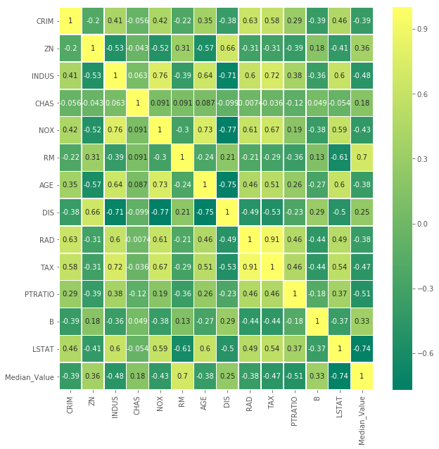

```python
fig, ax = plt.subplots(figsize=(10,10))
sns.heatmap(pearson_corr, annot=True, linewidths=.5, ax=ax, cmap='summer')
```

## Conclusion of Variable Correlations

- The binary variable **CHAS** does not have a strong correlation with any variable.
- The categorical variable **RAD** has a moderatly strong correlation with **CRIM** & **TAX**.
- The continuous variables with the strongest correlations are **DIS**, **NOX**, **AGE**, **LSTAT**, **RM** and **Median_Value**.
- RAD & CRIM: has a consistent positive correlation ranging from 0.56,0.63 and 0.73.
- Since our goal is to predict the **Median_Value** if we use simple linear regression **RM** or **LSTAT** should provide the best predictor variables.
- Using several different correlation methods gives higher confidence in especially with the **RAD** & **CRIM** and the **RAD** & **TAX** variables.

Table of Contents

# Visualizing Relationships

Let's split the features dataframe into three seperate dataframes to visually inspect for relationsips

```python
# Creating seperate dataframes for:
#1.The best predictor variables for Median_Value
#2 best correlated variables with the categorcial variable RAD
#3 The top most correlated variables
best_predictors = features.drop(['CRIM','ZN','INDUS','CHAS','NOX','AGE','DIS','RAD','TAX','PTRATIO'],axis=1)
cat_predictors = features.drop(['ZN','INDUS','CHAS','NOX','AGE','DIS','PTRATIO','LSTAT','RM','Median_Value'],axis=1)
most_corr = features.drop(['ZN','INDUS','CHAS','RAD','TAX','CRIM','PTRATIO'],axis=1)
```

### Visualizing the most correlated variables with Median Value

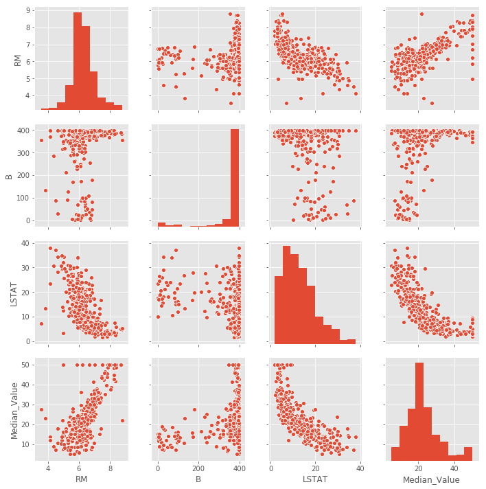

```python
sns.pairplot(best_predictors)
```

From the above graphs we can see linear relationships exist however **LSTAT** is skewed to the right. Since many statistical models require a normal distribution highly skewed data may distort the statistical model.

### Visualizing correlations with categorical variables

Continuous variables:

- CRIM
- TAX

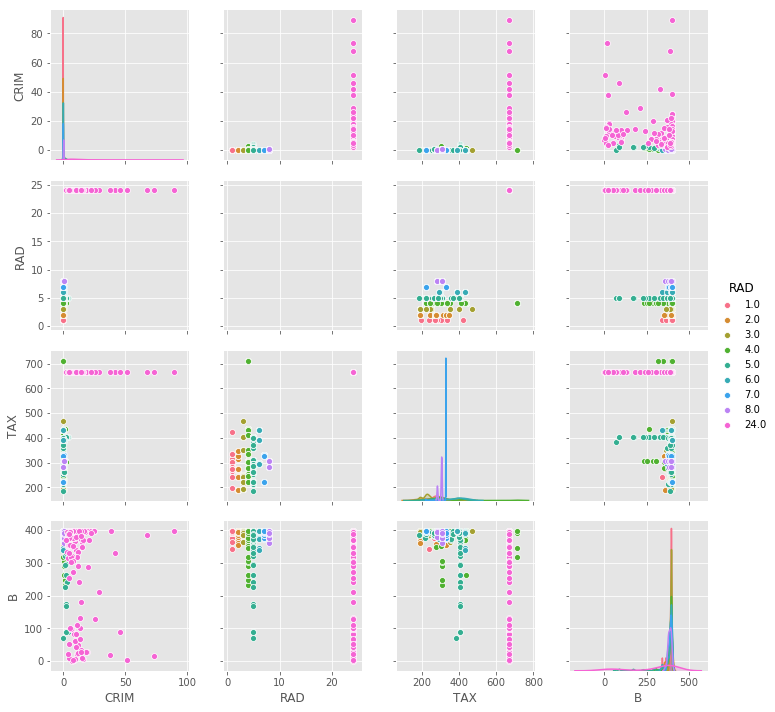

```python
sns.pairplot(cat_predictors,hue='RAD')
```

It is not easy to see how relationships in these categorical variables other methods such as Logistic Regression may work better

### Visually the most correlated variables

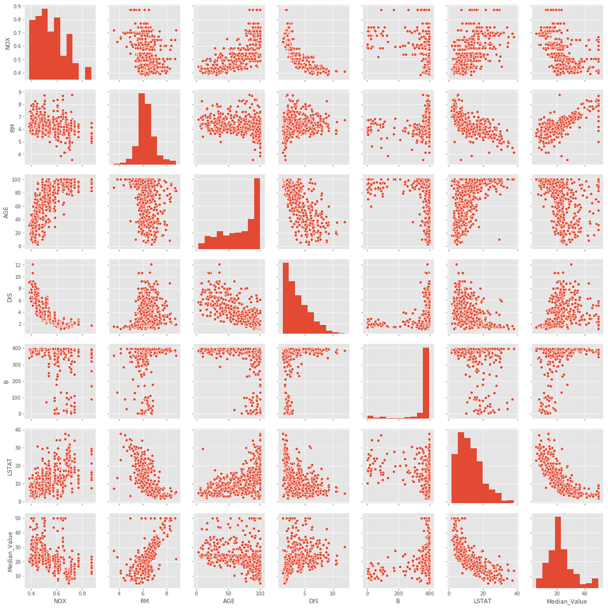

```python
sns.pairplot(most_corr)
```

From this graph we can see that there are several linear relationships and several of the variables are highly skewed.

Many statistical models assume the data has a normal distribution curve when the data is not normally distributed the statistical model can become unreliable and other models that do not require a normal distribution should be used. Another method is to perform a transformation on the data to obtain a normal distribution.

Table of Contents

#### The Normal Distribution

```python
Image(url= "https://studiousguy.com/wp-content/uploads/2019/04/Normal-Distribution-curve.jpg")
```

[figure not shown]

Skewness and kurtosis are the two primary measures of a normal distribution when it comes to the shape of the distribution. Skewness refers to how centered the data is and kurtosis refers to how tall or flat a data set is. The skewness and kurtosis can be measured mathematically to determine whether a dataset has a normal distribution.

### Measuring Skewness and Kurtosis

- If skewness is less an -1 or greater than 1 the distribution is highly skewed
- If skewness is between -1 -1/2 or between 1/2 and 1 the distribution is moderately skewed.
- If skewness is between -1/2 and 1/2, the distrubution is symmetric.
- If kurtosis is $\approx$ 3 it is called mesokurtic and is considered to be a normal distribution.
- If kurtosis is < 3 it is called platykurtic amd the distribution will appear very flat and broad.
- if the kurtosis is > 3 it is called leptokurtic and the distribution will appear skinny and tall.

```python
#Measuring the skewness for each variable

for i in features.columns:
    skewness = skew(features[i])
    print(f'Skewness: {i}: {skewness:.2f}')
```

```
Skewness: CRIM: 5.21
Skewness: ZN: 2.22
Skewness: INDUS: 0.29
Skewness: CHAS: 3.40
Skewness: NOX: 0.73
Skewness: RM: 0.40
Skewness: AGE: -0.60
Skewness: DIS: 1.01
Skewness: RAD: 1.00
Skewness: TAX: 0.67
Skewness: PTRATIO: -0.80
Skewness: B: -2.88
Skewness: LSTAT: 0.90
Skewness: Median_Value: 1.10
```

```python
#Measuring the kurtosis for each variable

for i in features.columns:
    k = stats.kurtosistest(features[i])
    print(f'Kurtosis: {i}: {k[0]:.2f}')
```

```
Kurtosis: CRIM: 13.26
Kurtosis: ZN: 7.26
Kurtosis: INDUS: -20.32
Kurtosis: CHAS: 9.89
Kurtosis: NOX: -0.21
Kurtosis: RM: 4.98
Kurtosis: AGE: -9.35
Kurtosis: DIS: 1.97
Kurtosis: RAD: -7.38
Kurtosis: TAX: -14.86
Kurtosis: PTRATIO: -1.45
Kurtosis: B: 9.05
Kurtosis: LSTAT: 1.99
Kurtosis: Median_Value: 4.34
```

Table of Contents